# Business Analytics Final Project: Predictive Analysis of Stroke

Yijie He

2024-02-13

# 1. Statement of Research Objectives

According to the World Health Organization (WHO) data, stroke is the second leading cause of death globally, accounting for approximately 11% of the total deaths.

Our research aims to harness machine learning to predict stroke occurrence, focusing on the impact of various health indicators. The objective is to identify key predictive variables that contribute to stroke risk, thereby enhancing early intervention strategies.

# 2. Background and Preparation

# 3. Methodology

Our approach involved rigorous data cleaning to ensure accuracy, followed by comprehensive data visualization to identify patterns and anomalies. We utilized logistic regression as our primary statistical technique, enabling us to model the probability of stroke events based on multiple predictors.

## 3.1 Descriptive Analysis

### 3.1.1 Overview of data we used

Overview of Dataset Variables

| Field_Name | Variable_Type | Description |
| --- | --- | --- |
| ID | Discrete | Unique identifier for each individual |
| gender | Discrete | Male, Female or Other |
| age | Continuous | Age of the patient |
| hypertension | Discrete | 0 if no hypertension, 1 if the patient has hypertension |
| heart_disease | Discrete | 0 if no heart disease, 1 if the patient has heart disease |
| work_type | Discrete | Children, Govt_job, Never_worked, Private, Self-employed |
| Residence_type | Discrete | Rural or Urban |
| avg_glucose_level | Continuous | The average glucose level of the patient |
| bmi | Continuous | Body Mass Index |
| smoking_status | Discrete | formerly smoked, never smoked, smokes, Unknown |
| ever_married | Discrete | Yes or No |
| stroke | Discrete | 1 if the patient had a stroke, otherwise 0 |

Here is the code used to convert the data to the correct type.

```r
> dt=read.csv("healthcare-dataset-stroke-data.csv")
> dt$bmi=as.numeric(dt$bmi)
> dt$bmi[is.na(dt$bmi)]=mean(dt$bmi,na.rm = T)
> dt=dt[,-1]
> dt$hypertension=as.factor(dt$hypertension)
> dt$heart_disease=as.factor(dt$heart_disease)
> dt$stroke=as.factor(dt$stroke)
> dt$gender=factor(dt$gender,levels=c("Male","Female","Other"))
> dt$ever_married=as.factor(dt$ever_married)
> dt$work_type=as.factor(dt$work_type)
> dt$Residence_type=as.factor(dt$Residence_type)
> dt$smoking_status=factor(dt$smoking_status,levels=c("Unknown","never smoked","smokes","formerly smoked"))
> set.seed(123456)
> index = sample(1:5110,3577)
> dt_train=dt[index,]
> dt_test = dt[-index,]
> write.csv(dt_train,"stroke_train.csv")
> write.csv(dt_test,"stroke_test.csv")
```

### 3.1.2 Data Cleaning

When loading the original dataset, we may encounter incorrect data types that need to be converted to the appropriate types for conducting logistic regression.

### 3.1.3 Visulization

Prior to constructing our predictive model, we conducted preliminary visualizations of the continuous variables in relation to stroke occurrences to intuitively grasp any potential correlations.

Figure 2.1 and 2.2 illustrate the distribution of BMI among individuals with and without stroke. Notably, the distribution of BMI in the non-stroke group demonstrates a pronounced heavy-tailed characteristic, providing a distinct distribution feature that could be advantageous for prediction purposes. Conversely, glucose levels display a clear positive correlation with the likelihood of stroke, with higher glucose levels being associated with a greater proportion of stroke cases compared to non-stroke; however, Figure 2.4, which depicts a scatter plot of BMI against glucose levels, does not exhibit a strong correlation between the two variables within stroke/non-stroke groups, suggesting clustering.

Among the continuous variables, age showed the most significant predictive power. As seen in Figure 2.3, there is a stark contrast in the age distribution between stroke and non-stroke cohorts, with the stroke-affected population heavily concentrated in the older age bracket. Figures 2.5 and 2.6, which analyze the relationship of age with the other two continuous variables, BMI and glucose levels, in stroke versus non-stroke contexts, reveal no significant correlations. There is a slight positive relationship between glucose levels and age, which could be attributed to the higher prevalence of diabetes in middle-aged and older populations.

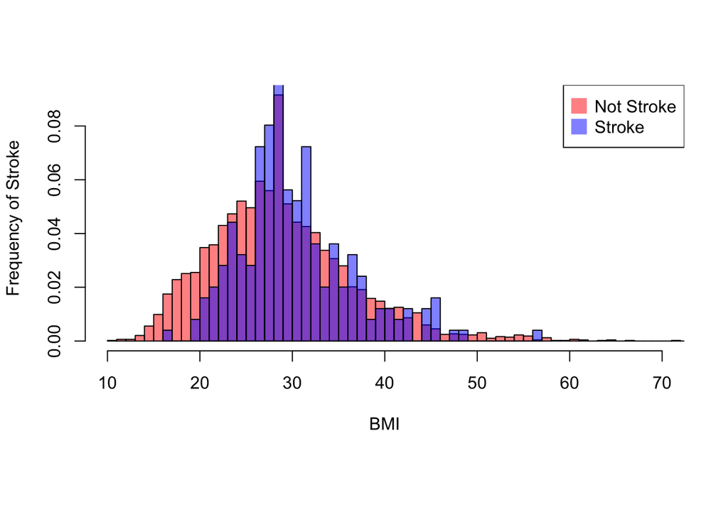

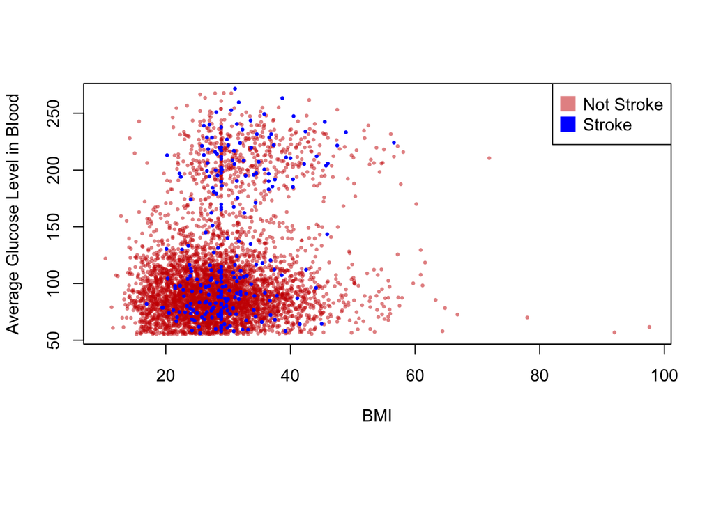

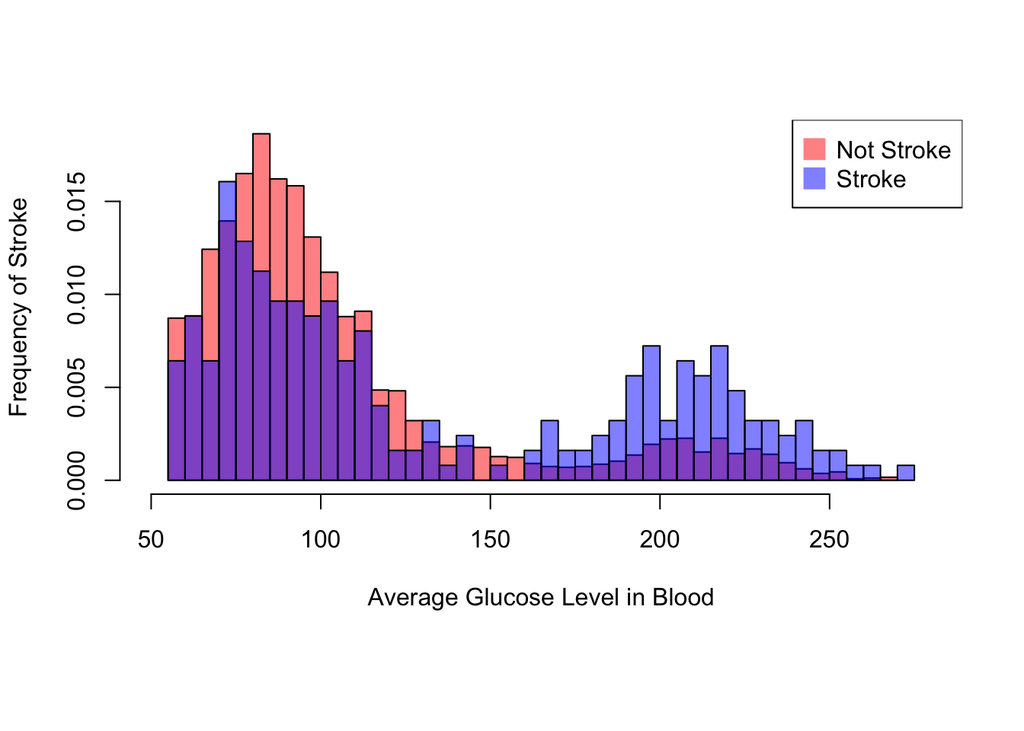

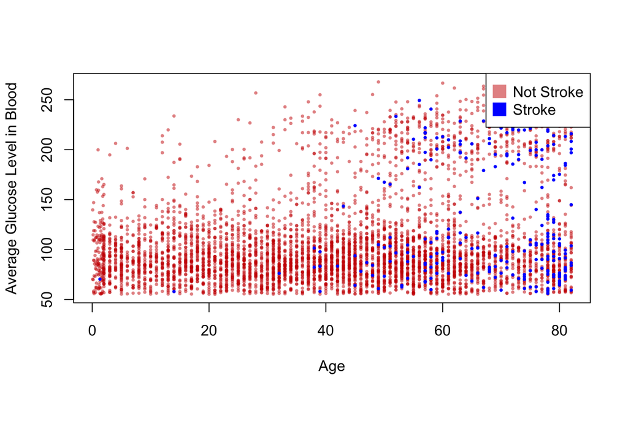

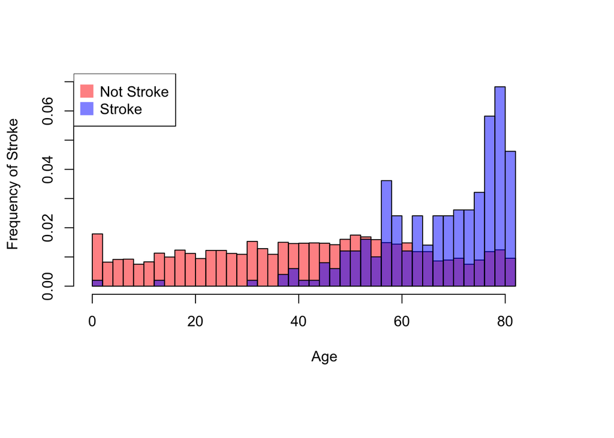

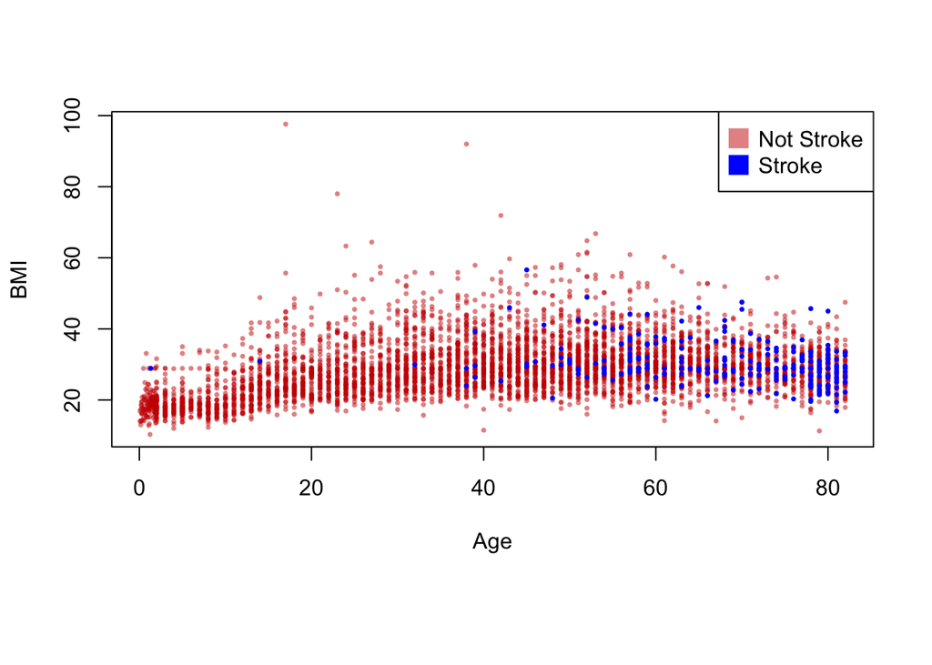

## 3.2 Correlation

To be intuitive, we assign numerical values to categorical variables, the more severe the situation is, the higher the number. Then we calculate the correlation matrix between variables to see if there is a risk of multicollinearity. From the picture we could say the risk of multicollinearity is low. But we will also double check later using vif.

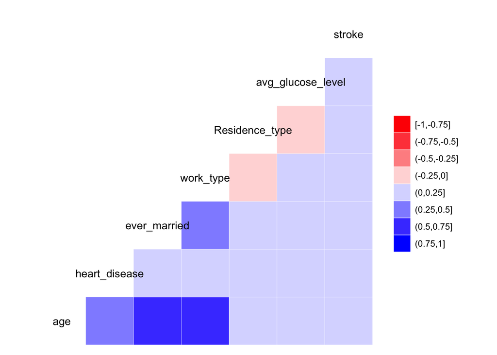

# 4. Logistic regression model and results

Now that we finished the visulization part, we have better qualitative understanding of the datasets, we want to analyse it quantitatively. To do the logistic regression, we need to introduce dummy variables to replace the original nomial variables We introduce dummy variables as follows

Dummy variable seeting.

| Original.Variable | New.Variable | Description |
| --- | --- | --- |
| Gender | Male | 1 for male; 0 for non-male |
| Gender | Female | 1 for female; 0 for non-female |
| Gender | Other | 1 for other gender; 0 for non-other gender |
| ever_married | ever_married | 1 for married; 0 for not married |
| Residence_type | Residence_type | 1 for urban; 0 for rural |
| work_type | work_govt | 1 for government job; 0 for non-government job |
| work_type | work_private | 1 for private job; 0 for non-private job |
| work_type | work_self | 1 for self-employed; 0 for non-self-employed |
| work_type | work_never | 1 for never worked; 0 for has worked |
| work_type | work_children | 1 for children; 0 for adult |
| smoking_status | smoking_never | 1 for never smoked; 0 for smoked |
| smoking_status | smoking_formerly | 1 for formerly smoked; 0 for never smoked |
| smoking_status | smoking_smokes | 1 for currently smoking; 0 for not currently smoking |
| smoking_status | smoking_unknown | 1 for unknown smoking status; 0 for known smoking status |

## 4.1 Logistic regression

Now it’s time for us to divide the train and test set and do the logistic regression. We get result as follows

### Coefficients of the Model

|  | Estimate | Std. Error | z value | Pr(>\|z\|) |
| --- | --- | --- | --- | --- |
| (Intercept) | -17.1303031 | 1455.3977644 | -0.0117702 | 0.9906090 |
| age | 0.0754425 | 0.0069665 | 10.8292992 | 0.0000000 |
| avg_glucose_level | 0.0046986 | 0.0014460 | 3.2494859 | 0.0011561 |
| bmi | 0.0061939 | 0.0133753 | 0.4630868 | 0.6433021 |
| Male | 10.4617327 | 1455.3975986 | 0.0071882 | 0.9942647 |
| Female | 10.4192185 | 1455.3975990 | 0.0071590 | 0.9942880 |
| hypertension | 0.3869442 | 0.1981524 | 1.9527601 | 0.0508480 |
| heart_disease | 0.1017655 | 0.2354140 | 0.4322832 | 0.6655356 |
| ever_married1 | -0.2121800 | 0.2694928 | -0.7873308 | 0.4310882 |
| Residence_type1 | 0.0889028 | 0.1662973 | 0.5346018 | 0.5929252 |
| work_self | -1.7059119 | 0.8915312 | -1.9134629 | 0.0556888 |
| work_govt | -1.6240168 | 0.8903884 | -1.8239421 | 0.0681608 |
| work_never | -10.7735511 | 374.3580024 | -0.0287787 | 0.9770411 |
| work_private | -1.1680730 | 0.8631214 | -1.3533125 | 0.1759558 |
| smoking_formerly | -0.0413929 | 0.2610638 | -0.1585549 | 0.8740196 |
| smoking_never | -0.1035520 | 0.2410873 | -0.4295208 | 0.6675443 |
| smoking_smokes | 0.3754646 | 0.2740063 | 1.3702774 | 0.1706003 |

### AIC

AIC: 1137.354

Now let us take a look at vif to check the risk of multicollinearity

```r
vif(fit)
```

```
##               age avg_glucose_level               bmi              Male
##      1.550264e+00      1.117554e+00      1.134413e+00      7.685790e+07
##            Female      hypertension     heart_disease      ever_married
##      7.685790e+07      1.072151e+00      1.090356e+00      1.147470e+00
##    Residence_type         work_self         work_govt        work_never
##      1.010632e+00      2.102256e+01      1.152327e+01      1.000004e+00
##      work_private  smoking_formerly     smoking_never    smoking_smokes
##      2.525145e+01      1.843275e+00      2.009452e+00      1.747969e+00
```

We could figure out that in the logistic regression, age and avg_glucose_level have significant impact on the stroke. But we also notice that there are a lot of statistically insignificant variables. And there is multicollinearity between male and female since there is one record of “other”. So it’s time for us to do the variable choosing. We simply use step function to choose the model that fits well

```r
step(fit)
```

[output not shown]

```r
fit2 = glm(formula = stroke ~ age + avg_glucose_level + hypertension + work_self +
             work_govt + smoking_smokes, family = binomial(link = "logit"), data = train)
summary(fit2)
```

```
##
## Call:
## glm(formula = stroke ~ age + avg_glucose_level + hypertension +
##     work_self + work_govt + smoking_smokes, family = binomial(link = "logit"),
##     data = train)
##
## Deviance Residuals:
##     Min       1Q   Median       3Q      Max
## -1.0742  -0.3206  -0.1705  -0.0829   3.7908
##
## Coefficients:
##                    Estimate Std. Error z value Pr(>|z|)
## (Intercept)       -7.623381   0.436339 -17.471  < 2e-16 ***
## age                0.071667   0.006227  11.508  < 2e-16 ***
## avg_glucose_level  0.004892   0.001388   3.524 0.000425 ***
## hypertension       0.387134   0.195305   1.982 0.047456 *
## work_self         -0.530450   0.203103  -2.612 0.009009 **
## work_govt         -0.474091   0.267102  -1.775 0.075906 .
## smoking_smokes     0.423099   0.208412   2.030 0.042346 *
## ---
## Signif. codes:  0 '***' 0.001 '**' 0.01 '*' 0.05 '.' 0.1 ' ' 1
##
## (Dispersion parameter for binomial family taken to be 1)
##
##     Null deviance: 1385.5  on 3576  degrees of freedom
## Residual deviance: 1107.1  on 3570  degrees of freedom
## AIC: 1121.1
##
## Number of Fisher Scoring iterations: 7
```

And we check for the McFadden’s pseudo R^2, we could figure out that it is between 0.2 and 0.4, which is pretty good.

```
## # R2 for Generalized Linear Regression
##        R2: 0.201
##   adj. R2: 0.200
```

## 4.2 Sensitivity and specificity check

Our accuracy is 95% if we choose a cutoff of 0.5, but all of our prediction is false, which is meaningless in the field of health diagonostics. So we find out the best cutoff level is 0.035 through trial and error. During this cutoff level, our sensitivity is 89.01% and specificity is 66.01%

Here is the trial and error process. First we want to draw a ROC graph to have a basic understanding of the range of a good threshold

[output not shown]

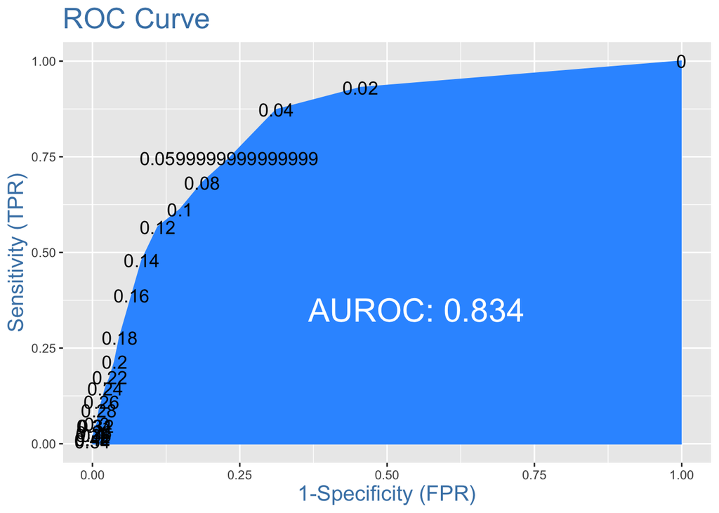

Then we try around the range

```r
library(InformationValue)

conf_matrix_list <- list(
  "Threshold 0.05" = confusionMatrix(actuals = train$stroke, predictedScores=train$estimatedstroke, threshold = 0.05),
  "Threshold 0.045" = confusionMatrix(actuals = train$stroke, predictedScores=train$estimatedstroke_mid2, threshold = 0.045),
  "Threshold 0.04" = confusionMatrix(actuals = train$stroke, predictedScores=train$estimatedstroke_mid, threshold = 0.04),
  "Threshold 0.035" = confusionMatrix(actuals = train$stroke, predictedScores=train$estimatedstroke_mid3, threshold = 0.04),
  "Threshold 0.03" = confusionMatrix(actuals = train$stroke, predictedScores=train$estimatedstroke_low, threshold = 0.04)
)

for (name in names(conf_matrix_list)) {
  cat(paste0("\n### ", name, "\n"))
  print(conf_matrix_list[[name]])
}
```

```
##
## ### Threshold 0.05
##      0   1
## 0 2509  33
## 1  895 140
##
## ### Threshold 0.045
##      0   1
## 0 2430  28
## 1  974 145
##
## ### Threshold 0.04
##      0   1
## 0 2342  22
## 1 1062 151
##
## ### Threshold 0.035
##      0   1
## 0 2247  19
## 1 1157 154
##
## ### Threshold 0.03
##      0   1
## 0 2130  16
## 1 1274 157
```

```r
# store the output of sensitivity and specificity
results <- data.frame(
  Threshold = c(0.05, 0.04, 0.045, 0.035, 0.03),
  Sensitivity = c(
    sensitivity(actuals = train$stroke, predictedScores = train$estimatedstroke, threshold = 0.05),
    sensitivity(actuals = train$stroke, predictedScores = train$estimatedstroke_mid2, threshold = 0.045),
    sensitivity(actuals = train$stroke, predictedScores = train$estimatedstroke_mid, threshold = 0.04),
    sensitivity(actuals = train$stroke, predictedScores = train$estimatedstroke_mid3, threshold = 0.035),
    sensitivity(actuals = train$stroke, predictedScores = train$estimatedstroke_low, threshold = 0.03)
  ),
  Specificity = c(
    specificity(actuals = train$stroke, predictedScores = train$estimatedstroke, threshold = 0.05),
    specificity(actuals = train$stroke, predictedScores = train$estimatedstroke_mid2, threshold = 0.045),
    specificity(actuals = train$stroke, predictedScores = train$estimatedstroke_mid, threshold = 0.04),
    specificity(actuals = train$stroke, predictedScores = train$estimatedstroke_mid3, threshold = 0.035),
    specificity(actuals = train$stroke, predictedScores = train$estimatedstroke_low, threshold = 0.03)
  )
)

# output
knitr::kable(results, caption = "Sensitivity and Specificity at Different Thresholds", align = 'c')
```

Sensitivity and Specificity at Different Thresholds

[output not shown]

## 4.3 Logistic regression model performance on test dataset

We could observe from the POC picture that AUC is 0.843, which means we have captured a good model

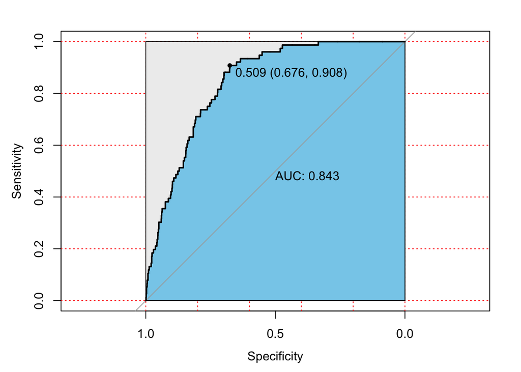

```
##     0  1
## 0 978  7
## 1 479 69
```

Sensitivity and Specificity at Threshold 0.035

| Metric | Value |
| --- | --- |
| Sensitivity | 0.9078947 |
| Specificity | 0.6712423 |

# 5. Conclusion